# Notebook Structure

# 6. How to Interpret Cumulative Density plot :

Key Features to Look For

Shape:

- A CDF always starts at 0 on the y-axis and increases to 1. It shows how the cumulative probability grows as the variable's value increases.
- Symmetric/Skewed: These terms don't apply to CDFs in the same way as they do to regular density plots or histograms. A CDF shows the accumulation of probability, not the shape of the distribution itself. However, you can infer skewness from the CDF's steepness:
- If the CDF rises quickly initially and then levels off slowly, it indicates a right-skewed distribution.
- If the CDF rises slowly initially and then steepens, it indicates a left-skewed distribution.
- Unimodal/Bimodal/Multimodal: These terms don't directly apply to CDFs. A CDF will show a smooth, increasing curve, even if the underlying distribution is multimodal. The steepness of the CDF can give you an idea where the modes of the distribution are.

Center:

- The "center" is represented by the value on the x-axis where the CDF reaches 0.5 (50%). This point corresponds to the median of the data.

Spread:

- The spread is indicated by the steepness of the CDF curve.
  - A steep CDF indicates a narrow spread (data points are concentrated).
  - A gradual CDF indicates a wide spread (data points are more dispersed).

Outliers:

- Outliers can be inferred from the CDF. If the CDF curve increases very slowly at the extreme ends of the x-axis, it suggests the presence of potential outliers.

Gaps:

- CDFs don't directly show gaps in the data in the same way histograms do. However, a long, flat section in the CDF might suggest a range of values where there are few data points.

In summary, a CDF shows the probability that a data point is less than or equal to a given value. You can use it to understand the median, spread, and skewness of the data.

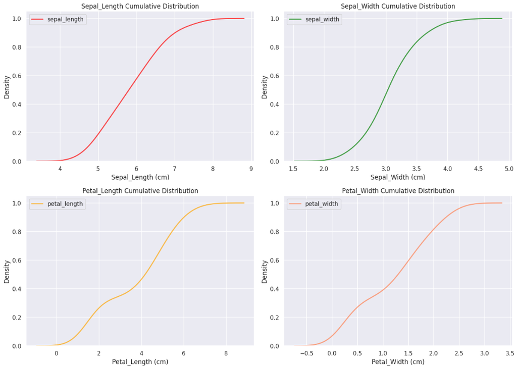

# 7. Example Business questions that can be answered by cumulative density plot

Here are some examples of business questions that can be answered using cumulative density plots:

Customer/Market Analysis:

- "What percentage of our customers spend less than $X per transaction?"
- "What is the distribution of customer ages, and what proportion falls within specific age brackets (e.g., under 25, between 25 and 40)?"
- "What proportion of website visitors spend less than Y minutes on the site?"
- "What is the cumulative distribution of customer income, and what percentage of our customer base earns above a certain threshold?"
- "How does customer spending behavior compare between different marketing campaigns?"

Sales and Revenue:

- "What proportion of sales falls below a certain revenue target?"
- "What is the distribution of sales cycle lengths, and what percentage of sales close within a specific timeframe?"
- "What percentage of products account for less than Z% of total revenue (Pareto analysis)?"

Risk Management:

- "What is the cumulative distribution of loan defaults, and what percentage of loans have a default rate below a certain level?"
- "What is the distribution of insurance claim amounts, and what percentage of claims are below a certain value?"
- "What is the cumulative probability of project cost overruns?"

Operations and Supply Chain:

- "What is the distribution of delivery times, and what percentage of orders are delivered within the promised timeframe?"
- "What is the cumulative distribution of production defect rates?"
- "What is the distribution of inventory levels, and what percentage of time is inventory below a critical threshold?"

Human Resources:

- "What is the distribution of employee salaries, and what percentage of employees earn less than a certain amount?"
- "What is the distribution of employee tenure, and what percentage of employees have been with the company for more than X years?"
- “What percentage of employees are below a certain performance level?”